# Lab 02

## Diamonds

Here, we will apply the methods shown in the notes to a data set of diamonds. This is a classic statistics data set used in a lot of notes that you may find online. Our variable of interest is the price of each diamond.

```r
set.seed(1)

diamond <- read_csv(file.path("data", "diamonds.csv")) %>%
  mutate(train_id = if_else(runif(n()) < 0.6, "train", "valid"))
diamond
```

```
## # A tibble: 1,000 x 11
##    price carat cut       color clarity depth table     x     y     z train_id
##    <dbl> <dbl> <chr>     <chr> <chr>   <dbl> <dbl> <dbl> <dbl> <dbl> <chr>
##  1   787 0.28  Ideal     F     VVS2     62.6    55  4.2   4.23  2.64 valid
##  2  2346 0.71  Very Good F     SI1      62.1    59  5.64  5.73  3.53 valid
##  3   478 0.26  Ideal     G     VS1      62.1    55  4.09  4.12  2.55 train
##  4  6389 1     Good      D     VS2      64.1    58  6.24  6.33  4.03 train
##  5  5818 1.2   Good      I     VS1      59.6    61  6.84  6.89  4.09 train
##  6  1369 0.570 Very Good G     SI1      63.4    57  5.26  5.21  3.32 valid
##  7  2278 0.75  Ideal     E     SI2      62.1    57  5.81  5.85  3.62 train
##  8   570 0.3   Ideal     F     VS1      62.6    57  4.29  4.34  2.7  valid
##  9  2980 0.64  Good      F     IF       58.6    61  5.69  5.71  3.34 train
## 10  2854 0.73  Premium   E     VS2      62      57  5.86  5.76  3.6  valid
## # … with 990 more rows
```

Start by creating a scatter plot with carat on the x-axis and price on the y-axis.

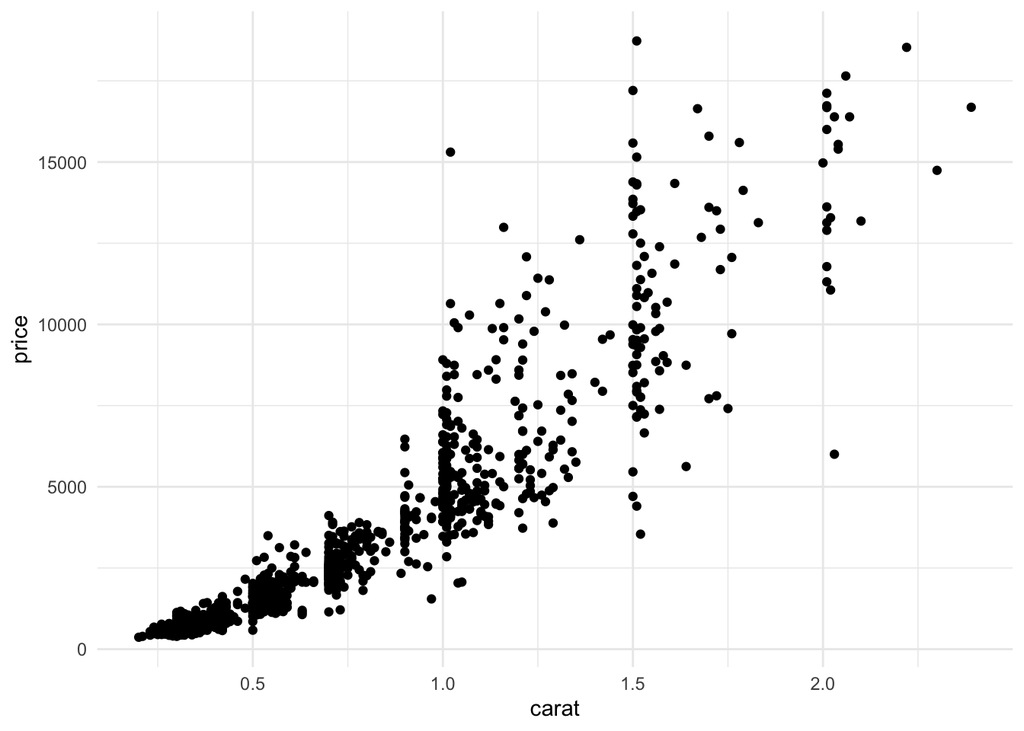

```r
diamond %>%
  ggplot(aes(carat, price)) +
    geom_point()
```

Before we start building predictive models, it is good to have a baseline for a good RMSE. Compute the RMSE on the train and valid sets using a model that just takes the mean value of `price`.

```r
diamond %>%
  mutate(pred_const = mean(price)) %>%
  group_by(train_id) %>%
  summarize(rmse = sqrt(mean((price - pred_const)^2)))
```

```
## # A tibble: 2 x 2
##   train_id  rmse
##   <chr>    <dbl>
## 1 train    3678.
## 2 valid    3565.
```

Now, buimd a model that predicts price as a function of a diamond’s carat on the training set. Calculate the RMSE for the training and validation sets.

```r
model <- diamond %>%
  filter(train_id == "train") %>%
  lm(price ~ carat, data = .)

diamond %>%
  mutate(pred_lm = predict(model, newdata = .)) %>%
  group_by(train_id) %>%
  summarize(rmse = sqrt(mean((price - pred_lm)^2)))
```

```
## # A tibble: 2 x 2
##   train_id  rmse
##   <chr>    <dbl>
## 1 train    1433.
## 2 valid    1545.
```

Now, add color (a categorical variable) into the model and compute the RMSE.

```r
model <- diamond %>%
  filter(train_id == "train") %>%
  lm(price ~ carat + color, data = .)

diamond %>%
  mutate(pred_lm = predict(model, newdata = .)) %>%
  group_by(train_id) %>%
  summarize(rmse = sqrt(mean((price - pred_lm)^2)))
```

```
## # A tibble: 2 x 2
##   train_id  rmse
##   <chr>    <dbl>
## 1 train    1365.
## 2 valid    1481.
```

Does the RMSE improve? **Answer**: Yes, by a little bit.

Now, print a summary of the model you just created.

```r
summary(model)
```

```
##
## Call:
## lm(formula = price ~ carat + color, data = .)
##
## Residuals:
##     Min      1Q  Median      3Q     Max
## -5311.0  -771.6   -33.7   605.9  7403.1
##
## Coefficients:
##             Estimate Std. Error t value Pr(>|t|)
## (Intercept) -2322.78     177.62 -13.077  < 2e-16 ***
## carat        8004.62     133.34  60.032  < 2e-16 ***
## colorE        -72.20     198.54  -0.364   0.7162
## colorF        115.70     202.27   0.572   0.5675
## colorG         89.04     197.55   0.451   0.6524
## colorH       -399.59     215.18  -1.857   0.0638 .
## colorI       -992.23     241.20  -4.114 4.44e-05 ***
## colorJ      -1878.43     346.56  -5.420 8.64e-08 ***
## ---
## Signif. codes:  0 '***' 0.001 '**' 0.01 '*' 0.05 '.' 0.1 ' ' 1
##
## Residual standard error: 1374 on 599 degrees of freedom
## Multiple R-squared:  0.8622, Adjusted R-squared:  0.8606
## F-statistic: 535.4 on 7 and 599 DF,  p-value: < 2.2e-16
```

For a given size, what color seems to be the most expensive? **Answer** F.

Now, fit a model that uses carat and clarity to predict the price of a diamond. Compute the RMSE of this model and compare to the previous two models.

```r
model <- diamond %>%
  filter(train_id == "train") %>%
  lm(price ~ carat + clarity, data = .)

diamond %>%
  mutate(pred_lm = predict(model, newdata = .)) %>%
  group_by(train_id) %>%
  summarize(rmse = sqrt(mean((price - pred_lm)^2)))
```

```
## # A tibble: 2 x 2
##   train_id  rmse
##   <chr>    <dbl>
## 1 train    1187.
## 2 valid    1268.
```

Modify the previous model to include a different slope and interecept for each clarity. Again, compute the RMSE.

```r
model <- diamond %>%
  filter(train_id == "train") %>%
  lm(price ~ carat * clarity, data = .)

diamond %>%
  mutate(pred_lm = predict(model, newdata = .)) %>%
  group_by(train_id) %>%
  summarize(rmse = sqrt(mean((price - pred_lm)^2)))
```

```
## # A tibble: 2 x 2
##   train_id  rmse
##   <chr>    <dbl>
## 1 train    1125.
## 2 valid    1183.
```

Takign the model from the previous question, predict prices for all of the diamands and plot the fit on a plot with carat on the x-axis, price on the y-axis, and lines colored by clarity. Verify that the lines have different slopes and intercepts.

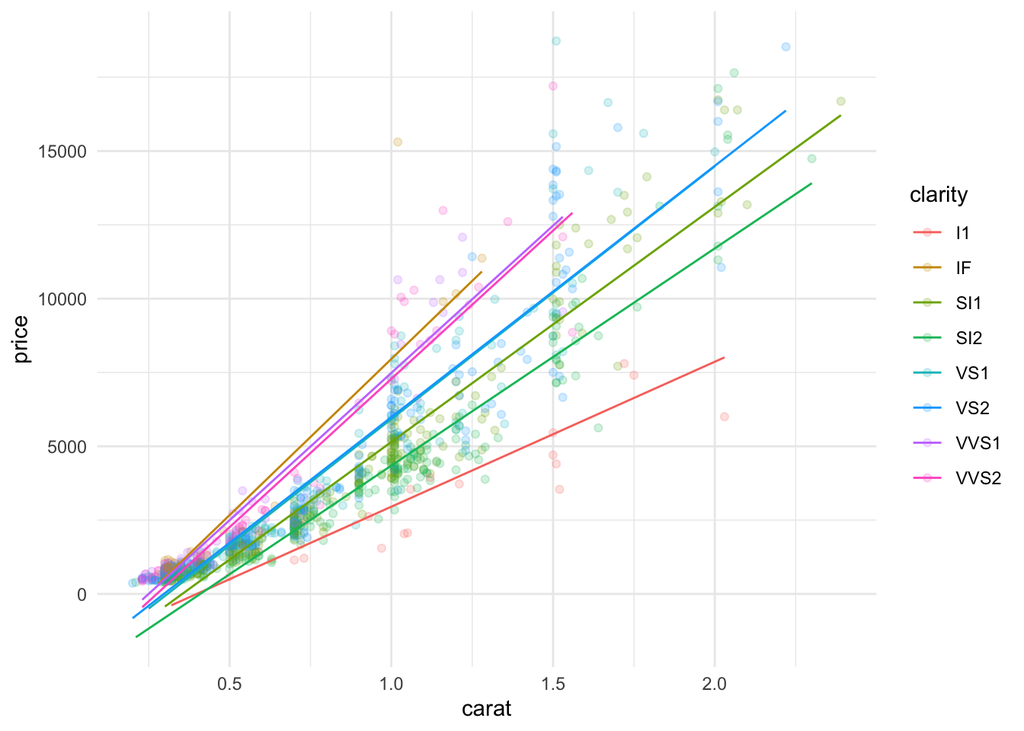

```r
diamond %>%
  mutate(pred_lm = predict(model, newdata = .)) %>%
  ggplot(aes(carat, price)) +
    geom_point(aes(color = clarity), alpha = 0.2) +
    geom_line(aes(y = pred_lm, color = clarity))
```

The relationship between carat and price seems non-linear. Fit a linear regression using a 5th order polynomial of carat to predict the price of a diamond. Print out the RMSE.

```r
model <- diamond %>%
  filter(train_id == "train") %>%
  lm(price ~ poly(carat, 5), data = .)

diamond %>%
  mutate(pred_lm = predict(model, newdata = .)) %>%
  group_by(train_id) %>%
  summarize(rmse = sqrt(mean((price - pred_lm)^2)))
```

```
## # A tibble: 2 x 2
##   train_id  rmse
##   <chr>    <dbl>
## 1 train    1328.
## 2 valid    1496.
```

Plot the fit from the previous model (a scatter plot with a line through the data showing the fitted values). Verify that the fit is non-linear.

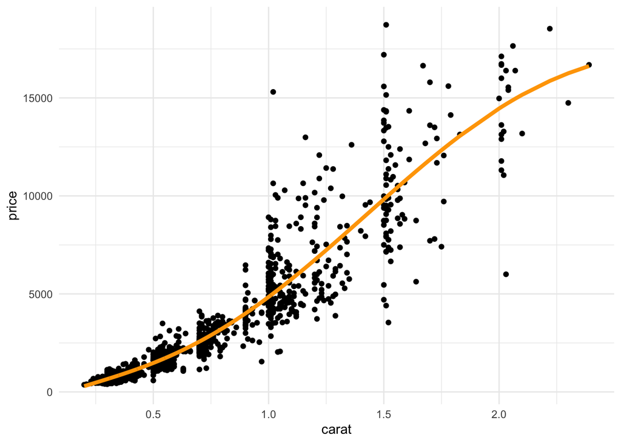

```r
diamond %>%
  mutate(pred_lm = predict(model, newdata = .)) %>%
  ggplot(aes(carat, price)) +
    geom_point() +
    geom_line(aes(y = pred_lm), color = "orange", size = 1.5)
```

The 4 C’s that determine a diamond’s prices are: cut, color, clarity, and carat (weight). Build a model that uses these four variables to predict the price of a diamon and print out the RMSE.

```r
model <- diamond %>%
  filter(train_id == "train") %>%
  lm(price ~ carat + cut + color + clarity, data = .)

diamond %>%
  mutate(pred_lm = predict(model, newdata = .)) %>%
  group_by(train_id) %>%
  summarize(rmse = sqrt(mean((price - pred_lm)^2)))
```

```
## # A tibble: 2 x 2
##   train_id  rmse
##   <chr>    <dbl>
## 1 train    1066.
## 2 valid    1138.
```

```r
model <- diamond %>%
  filter(train_id == "train") %>%
  lm(price ~ carat*cut*color*clarity, data = .)

diamond %>%
  mutate(pred_lm = predict(model, newdata = .)) %>%
  group_by(train_id) %>%
  summarize(rmse = sqrt(mean((price - pred_lm)^2)))
```

```
## # A tibble: 2 x 2
##   train_id   rmse
##   <chr>     <dbl>
## 1 train      581.
## 2 valid    21611.
```

## Cars

As a second data set, we will look at another class statistical programming data set of car models. The variable of interest is called `cty`, the fuel efficiency of the car in city traffic (miles per gallon).

```r
set.seed(1)

mpg <- read_csv(file.path("data", "mpg.csv")) %>%
  mutate(train_id = if_else(runif(n()) < 0.6, "train", "valid"))
mpg
```

```
## # A tibble: 234 x 9
##      cty displ   cyl drv     hwy class   manufacturer  year train_id
##    <dbl> <dbl> <dbl> <chr> <dbl> <chr>   <chr>        <dbl> <chr>
##  1    18   1.8     4 f        29 compact audi          1999 valid
##  2    21   1.8     4 f        29 compact audi          1999 valid
##  3    20   2       4 f        31 compact audi          2008 train
##  4    21   2       4 f        30 compact audi          2008 train
##  5    16   2.8     6 f        26 compact audi          1999 train
##  6    18   2.8     6 f        26 compact audi          1999 valid
##  7    18   3.1     6 f        27 compact audi          2008 train
##  8    18   1.8     4 4        26 compact audi          1999 valid
##  9    16   1.8     4 4        25 compact audi          1999 train
## 10    20   2       4 4        28 compact audi          2008 valid
## # … with 224 more rows
```

### Predicting with hwy

One variable in the data set is called `hwy`. It gives the fuel effiency for a car driving on the highway. As you might expect, this is a very good predictor of a car’s fuel efficiency in the city. To start, let’s get the RMSE of a model that just uses the mean of the `cty` variable for prediction.

```r
mpg %>%
  mutate(pred = mean(cty)) %>%
  group_by(train_id) %>%
  summarize(rmse = sqrt(mean((pred - cty)^2)))
```

```
## # A tibble: 2 x 2
##   train_id  rmse
##   <chr>    <dbl>
## 1 train     4.52
## 2 valid     3.80
```

Now fit a model on the training data where the highway fuel efficency is used to predict the city fuel efficency. Print out a summary of the model.

```r
model <- mpg %>%
  filter(train_id == "train") %>%
  lm(cty ~ hwy, data = .)

summary(model)
```

```
##
## Call:
## lm(formula = cty ~ hwy, data = .)
##
## Residuals:
##     Min      1Q  Median      3Q     Max
## -2.8981 -0.6861  0.1219  0.7179  4.4859
##
## Coefficients:
##             Estimate Std. Error t value Pr(>|t|)
## (Intercept)  0.34822    0.42080   0.828    0.409
## hwy          0.70200    0.01734  40.483   <2e-16 ***
## ---
## Signif. codes:  0 '***' 0.001 '**' 0.01 '*' 0.05 '.' 0.1 ' ' 1
##
## Residual standard error: 1.272 on 139 degrees of freedom
## Multiple R-squared:  0.9218, Adjusted R-squared:  0.9213
## F-statistic:  1639 on 1 and 139 DF,  p-value: < 2.2e-16
```

According to the model, do you expect the city fuel efficiency to be higher in the city or the highway? **Answer** The value on the highway is higher, hence the coefficient of 0.7, which is less than 1. The positive intercept will not overtake this given the range of the `hwy` variable.

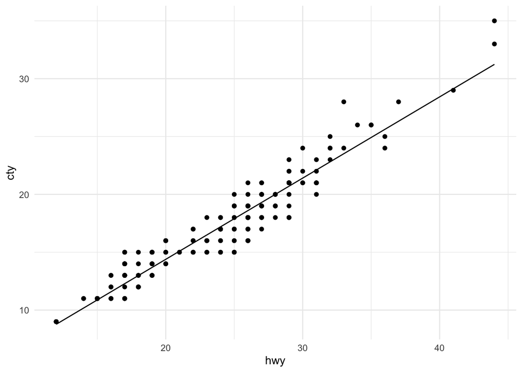

```r
mpg %>%
  mutate(pred = predict(model, newdata = .)) %>%
  ggplot(aes(hwy, cty)) +
    geom_point() +
    geom_line(aes(y = pred))
```

Now, compute the RMSE of this model. Verify that it is much lower than the constant model.

```r
mpg %>%
  mutate(pred = predict(model, newdata = .)) %>%
  group_by(train_id) %>%
  summarize(rmse = sqrt(mean((pred - cty)^2)))
```

```
## # A tibble: 2 x 2
##   train_id  rmse
##   <chr>    <dbl>
## 1 train     1.26
## 2 valid     1.24
```

Now, let’s try to re-fit this model using the matrix notation in R. To start, create a model matrix `X` and response vector `y` based on the same model you fit above. Print the head of the matrix.

```r
mf <- model.frame(cty ~ hwy, data = mpg)
mt <- attr(mf, "terms")
y <- model.response(mf)
X <- model.matrix(mt, mf)

head(X)
```

```
##   (Intercept) hwy
## 1           1  29
## 2           1  29
## 3           1  31
## 4           1  30
## 5           1  26
## 6           1  26
```

Now, create a training design matrix and response vector.

```r
X_train <- X[mpg$train_id == "train", ]
y_train <- y[mpg$train_id == "train"]
```

And fit the regression using `lm.fit`. Verify that the coefficients are very close (up to rounding) to the model you had from the `lm` function.

```r
beta <- lm.fit(X_train, y_train)$coef
beta
```

```
## (Intercept)         hwy
##   0.3482152   0.7019951
```

And then re-compute the RMSE to verify that it is the same as in the previous model.

```r
mpg %>%
  mutate(pred = X %*% beta) %>%
  group_by(train_id) %>%
  summarize(rmse = sqrt(mean((pred - cty)^2)))
```

```
## # A tibble: 2 x 2
##   train_id  rmse
##   <chr>    <dbl>
## 1 train     1.26
## 2 valid     1.24
```

Finally, just to show that it is possible, use the matrix product formulation at the bottom of my notes to show that you again get the same coefficients.

```r
solve(crossprod(X_train), crossprod(X_train, y_train))
```

```
##                  [,1]
## (Intercept) 0.3482152
## hwy         0.7019951
```

### Predicting with engine size (displ)

For one last model, create a scatter plot with the variable `displ` (the engine displacement; you can think of it as the size of the engine) on the x-axis and the city fuel efficency on the y-axis.

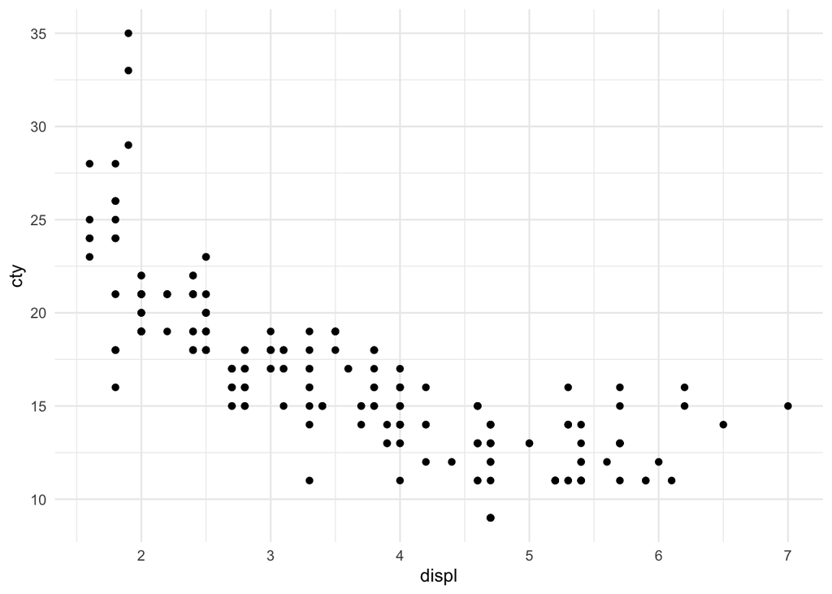

```r
mpg %>%
  ggplot(aes(displ, cty)) +
    geom_point()
```

You should notice that the relationship is non-linear. Fit a regression model predicting city fuel efficiency with the engine displacement using a 4th order polynomial expansion. Print out the model coefficients.

```r
model <- mpg %>%
  filter(train_id == "train") %>%
  lm(cty ~ poly(displ, 4), data = .)

summary(model)
```

```
##
## Call:
## lm(formula = cty ~ poly(displ, 4), data = .)
##
## Residuals:
##     Min      1Q  Median      3Q     Max
## -7.7372 -1.3955 -0.1342  1.2690 12.2468
##
## Coefficients:
##                 Estimate Std. Error t value Pr(>|t|)
## (Intercept)      16.8227     0.2051  82.010  < 2e-16 ***
## poly(displ, 4)1 -42.0880     2.4358 -17.279  < 2e-16 ***
## poly(displ, 4)2  16.2146     2.4358   6.657 6.32e-10 ***
## poly(displ, 4)3  -1.8565     2.4358  -0.762   0.4473
## poly(displ, 4)4   5.4703     2.4358   2.246   0.0263 *
## ---
## Signif. codes:  0 '***' 0.001 '**' 0.01 '*' 0.05 '.' 0.1 ' ' 1
##
## Residual standard error: 2.436 on 136 degrees of freedom
## Multiple R-squared:  0.7193, Adjusted R-squared:  0.711
## F-statistic: 87.13 on 4 and 136 DF,  p-value: < 2.2e-16
```

Now, plot the model fit to verify that it visually fits the data well.

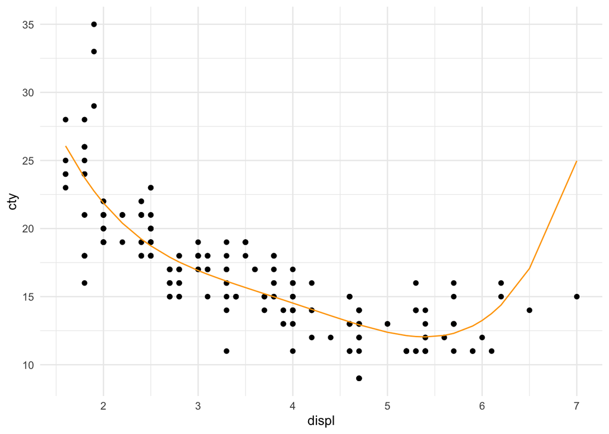

```r
mpg %>%
  mutate(pred = predict(model, newdata = .)) %>%
  ggplot(aes(displ, cty)) +
    geom_point() +
    geom_line(aes(y = pred), color = "orange")
```

It will also be interesting to add in a categorical variable. Fit a regression model predicting city fuel efficiency with the engine displacement using a 4th order polynomial expansion and include the categorical variable drv. Print out the model coefficients.

```r
model <- mpg %>%
  filter(train_id == "train") %>%
  lm(cty ~ poly(displ, 4) + drv, data = .)

summary(model)
```

```
##
## Call:
## lm(formula = cty ~ poly(displ, 4) + drv, data = .)
##
## Residuals:
##     Min      1Q  Median      3Q     Max
## -6.2770 -1.2091  0.1351  1.2506 12.0789
##
## Coefficients:
##                 Estimate Std. Error t value Pr(>|t|)
## (Intercept)      15.4653     0.3325  46.516  < 2e-16 ***
## poly(displ, 4)1 -35.9876     3.3814 -10.643  < 2e-16 ***
## poly(displ, 4)2  12.9682     2.3883   5.430 2.57e-07 ***
## poly(displ, 4)3  -3.3276     2.2687  -1.467   0.1448
## poly(displ, 4)4   5.6580     2.2553   2.509   0.0133 *
## drvf              2.3691     0.5325   4.449 1.80e-05 ***
## drvr              1.8931     0.7292   2.596   0.0105 *
## ---
## Signif. codes:  0 '***' 0.001 '**' 0.01 '*' 0.05 '.' 0.1 ' ' 1
##
## Residual standard error: 2.249 on 134 degrees of freedom
## Multiple R-squared:  0.7643, Adjusted R-squared:  0.7537
## F-statistic: 72.41 on 6 and 134 DF,  p-value: < 2.2e-16
```

As in the previous section, we are going to try to produce a model matrix to fit the same model using `lm.fit`. Start by creating the model matrix and response vector:

```r
mf <- model.frame(cty ~ poly(displ, 4) + drv, data = mpg)
mt <- attr(mf, "terms")
y <- model.response(mf)
X <- model.matrix(mt, mf)

head(X)
```

```
##   (Intercept) poly(displ, 4)1 poly(displ, 4)2 poly(displ, 4)3 poly(displ, 4)4
## 1           1     -0.08477275      0.08582274     -0.07489783      0.05244149
## 2           1     -0.08477275      0.08582274     -0.07489783      0.05244149
## 3           1     -0.07463123      0.05524854     -0.02342339     -0.01390341
## 4           1     -0.07463123      0.05524854     -0.02342339     -0.01390341
## 5           1     -0.03406512     -0.03410834      0.06397728     -0.03985216
## 6           1     -0.03406512     -0.03410834      0.06397728     -0.03985216
##   drvf drvr
## 1    1    0
## 2    1    0
## 3    1    0
## 4    1    0
## 5    1    0
## 6    1    0
```

Then create a model matrix and response vector just for the training set.

```r
X_train <- X[mpg$train_id == "train", ]
y_train <- y[mpg$train_id == "train"]
```

And fit the regression using `lm.fit`.

```r
beta <- lm.fit(X_train, y_train)$coef
beta
```

```
##     (Intercept) poly(displ, 4)1 poly(displ, 4)2 poly(displ, 4)3 poly(displ, 4)4
##       15.554576      -42.922946       20.888444        1.290693       11.564821
##            drvf            drvr
##        2.369076        1.893074
```

Look at the coefficients and compare to the ones in the model with with `lm()`. They are not the same! The last two are, but the others are all different. Compute the RMSE of the model:

```r
mpg %>%
  mutate(pred = X %*% beta) %>%
  group_by(train_id) %>%
  summarize(rmse = sqrt(mean((pred - cty)^2)))
```

```
## # A tibble: 2 x 2
##   train_id  rmse
##   <chr>    <dbl>
## 1 train     2.19
## 2 valid     2.16
```

Confusingly, this **is** the same. What’s going on here?!

Run the code below to see the matrix product XtX, rounded to 10 decimal places:

```r
round(crossprod(X), 10)
```

```
##                 (Intercept) poly(displ, 4)1 poly(displ, 4)2 poly(displ, 4)3
## (Intercept)             234        0.000000       0.0000000      0.00000000
## poly(displ, 4)1           0        1.000000       0.0000000      0.00000000
## poly(displ, 4)2           0        0.000000       1.0000000      0.00000000
## poly(displ, 4)3           0        0.000000       0.0000000      1.00000000
## poly(displ, 4)4           0        0.000000       0.0000000      0.00000000
## drvf                    106       -4.909018       0.7797605      0.63434824
## drvr                     25        2.160405       0.9179910     -0.01994379
##                 poly(displ, 4)4          drvf        drvr
## (Intercept)         0.000000000 106.000000000 25.00000000
## poly(displ, 4)1     0.000000000  -4.909018489  2.16040500
## poly(displ, 4)2     0.000000000   0.779760547  0.91799099
## poly(displ, 4)3     0.000000000   0.634348238 -0.01994379
## poly(displ, 4)4     1.000000000   0.008665853 -0.02814376
## drvf                0.008665853 106.000000000  0.00000000
## drvr               -0.028143762   0.000000000 25.00000000
```

What happens is that when R creates a polynomial expansion it uses an algorithm to ensure that the polynomial coefficients are uncorrelated. This is much more numerically stable than using, say, x, x^2, x^3, and so forth. In our formulation here the difference is that in lm() the polynomials were designed to be orthogonal on the training data; in the formulation here they are orthogonal on the entire data set. The fitted values are the same (it is still just a 4th order expansion), but the specific beta values are different.